# Class 23: Odd Ratios

Fisher/O’Connell/Hughes

## Odds Ratios: A way to compare factors on binary outcomes

Let’s revisit the cancer prevalence data from last time. Before we calculated the odds of lung cancer in a 60-year old male who has smoked at least 10 years (call this a “long-term” smoker):

```r
cancerprev <- read.csv("cancerprev.csv")
cancerprev <- cancerprev %>%
  mutate(LongTerm.Smoker = yrssmoke >= 10)
xtabs(~LongTerm.Smoker + cancer, data=cancerprev)
```

```
##                cancer
## LongTerm.Smoker   0   1
##           FALSE 116  13
##           TRUE   33  38
```

- The **overall odds** of having cancer are $\frac{13+38}{116+33} = \frac{51}{149} = 0.3422$.
- The odds of a long-term smoker having cancer are $\frac{38}{33} = 1.1515$ while the odds of a non-long-term smoker (that is, less than 10 years) are $\frac{13}{116} = 0.11207$

By looking at the numbers, it seems apparent that long-term smokers are more likely to have cancer. We can make a direct comparison via an **odds ratio**. That is, the ratio of the two odds

$$\frac{1.1515}{0.11207} = 10.27483$$

So the odds of having cancer for a long-term smoker is **more than 10 times that** of a non-long-term smoker (based on our definition of “long-term” smoking).

**Important Note:** If the time of smoking had little to no influence on the odds of having cancer, **we would expect the odds ratio to take on a value close to 1**. Here 10.27 > 1. (In fact, *much* greater than 1).

## Example: The Framingham Heart Study

*Quoted from the Framingham Heart Study website at* **framinghamheartstudy.org**:

Cardiovascular disease (CVD) is the leading cause of death and serious illness in the United States. In 1948, the Framingham Heart Study - under the direction of the National Heart Institute (now known as the National Heart, Lung, and Blood Institute or NHLBI) - embarked on an ambitious project in health research. At the time, little was known about the general causes of heart disease and stroke, but the death rates for CVD had been increasing steadily since the beginning of the century and had become an American epidemic. The Framingham Heart Study became a joint project of the National Heart, Lung and Blood Institute and Boston University.

The objective of the Framingham Heart Study was to identify the common factors or characteristics that contribute to CVD by following its development over a long period of time in a large group of participants who had not yet developed overt symptoms of CVD or suffered a heart attack or stroke. The researchers recruited 5,209 men and women between the ages of 30 and 62 from the town of Framingham, Massachusetts, and began the first round of extensive physical examinations and lifestyle interviews that they would later analyze for common patterns related to CVD development. Since 1948, the subjects have continued to return to the study every two years for a detailed medical history, physical examination, and laboratory tests, and in 1971, the Study enrolled a second generation - 5,124 of the original participants’ adult children and their spouses - to participate in similar examinations. The study continues with new cohorts to this day.

The datafile `framingham.txt` contains selected variables for 4,658 participants in the study. The variables are:

- `age` - subject age in years
- `sbp` - systolic blood pressure
- `dbp` - diastolic blood pressure
- `scl` - serum cholesterol level
- `bmi` - BMI (Body Mass Index)
- `chdfate` - Indicator of whether the subject has been dignosed (1) or not (0) with coronary heart disease

```r
framingham <- read.table("framingham.txt", header=TRUE)
head(framingham)
```

```
##   id age sbp dbp scl  bmi chdfate
## 1  1  60 106  68 239 22.9       0
## 2  2  46 118  78 252 22.0       1
## 3  3  49 135  85 284 30.6       0
## 4  4  52 154  92 196 36.1       0
## 5  5  55 162 102 275 29.3       0
## 6  6  62 136  66 313 25.4       0
```

**Body Mass Index (BMI)** is typically broken up into 4 distinct categories. By looking at the odds ratios of these categories, let’s determine if BMI appears to influence the prevelance of heart disease in the `framingham` dataset.

First, let’s create the standard BMI categories (visit https://www.cancer.org/cancer/cancer-causes/diet-physical-activity/body-weight-and-cancer-risk/adult-bmi.html):

```r
framingham <- framingham %>%
  mutate(BMI.Category = case_when(bmi < 18.5 ~ "Underweight",
                                  bmi <= 24.9 ~ "Normal weight",
                                  bmi <= 29.9 ~ "Overweight",
                                  bmi >= 30 ~ "Obese"))
xtabs(~ BMI.Category + chdfate, data=framingham)
```

```
##                chdfate
## BMI.Category       0    1
##   Normal weight 1609  530
##   Obese          350  246
##   Overweight    1171  681
##   Underweight     63    8
```

What are the odds of CHD for underweight, normal, overweight and obese, respectively?

```r
# Underweight
8/63
```

```
## [1] 0.1269841
```

```r
# Normal Weight
530/1609
```

```
## [1] 0.3293971
```

```r
# Overweight
681/1171
```

```
## [1] 0.5815542
```

```r
# Obese
246/350
```

```
## [1] 0.7028571
```

It looks like the larger the BMI, the higher the risk of heart disease. We can compare the odds:

What is the OR (odds ratio) of CHD for normal weight vs. underweight people?

```r
(530/1609)/(8/63)
```

```
## [1] 2.594002
```

So a normal weight person is about 2.59 times more likely to suffer from heart disease than someone who is underweight.

Now let’s calculate the OR (odds ratio) of CHD to compare obese persons to each of the three lower weight classes.

```r
# Obese vs. overweight
(246/350)/(681/1171)
```

```
## [1] 1.208584
```

```r
# Obese vs. normal weight
(246/350)/(530/1609)
```

```
## [1] 2.133768
```

```r
# Obese vs. underweight
(246/350)/(8/63)
```

```
## [1] 5.535
```

An obese person is 1.2 times more likely to suffer from heart disease than an overweight person, 2.13 times more likely than a normal weight person, and 5.5 times more likely than an underweight person.

## In-class Assignment

For this assignment, we will continue to use the Framingham heart data.

### Question 1

Consider the following code:

```r
heart.agg <- framingham %>%
  mutate(bmi = floor(bmi) ) %>%
  group_by(bmi) %>%
  filter(n() > 15) %>%
  summarize(prop = mean(chdfate))
```

Briefly explain what the code does. That is, exactly what are the `mutate`, `group_by`, `filter` and `summarize` functions doing with the `framingham` dataset?

*ANSWER: It will take in a float value and will always round down to the nearest closest integer. Mutate is changing the current object given parameters, group_by organizes the results, filter will take out the organized and changed results and remove entries based on parameters, and finally the summarize function will get key facts about the result and display them.*

### Question 2

Make a scatterplot of the proportion of those with heart disease as a function of the `bmi` values from the `heart.agg` dataset. What is the *range* of the proportions? Hint: think high school mathematics! That is, the *range* (valid set of $y$-values) of a function.

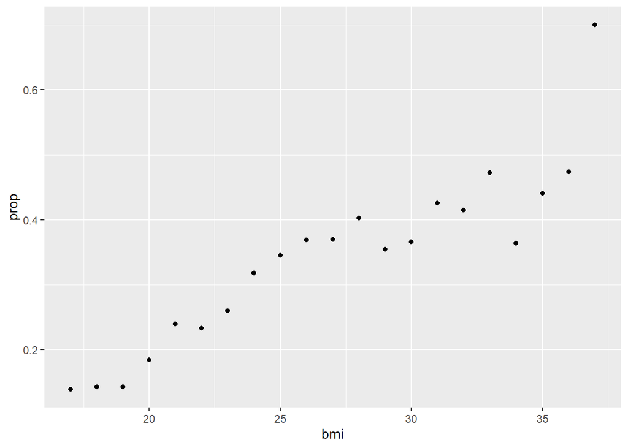

```r
ggplot(data=heart.agg, aes(x = bmi, y = prop)) + geom_point()
```

*ANSWER:*

### Question 3

Create a new variable, called `odds`, in the dataset `heart.agg` that is the odds a patient has heart disease. Recall, $Odds = \frac{\#~success}{\#~failture} = \frac{p}{1-p}$. Make a scatterplot of the odds of heart disease as a function of bmi. What is the *range* of the odds?

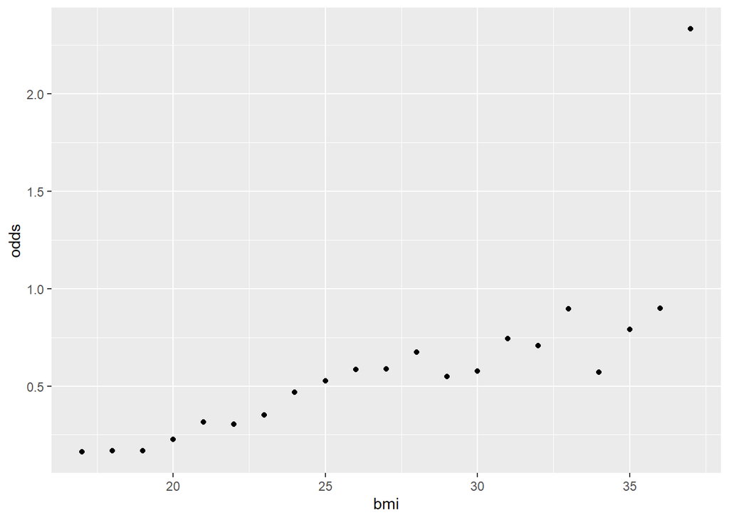

```r
heart.agg <- heart.agg %>%
  mutate(odds = (prop / (1-prop)))

ggplot(data=heart.agg, aes(x = bmi, y = odds)) + geom_point()
```

*ANSWER:*

### Question 4

Create a new variable, called `log.odds`, in the dataset `heart.agg` that is the log odds a patient has heart disease. Make a scatterplot of the log odds of heart disease as a function of bmi. What is the *range* of the log odds?

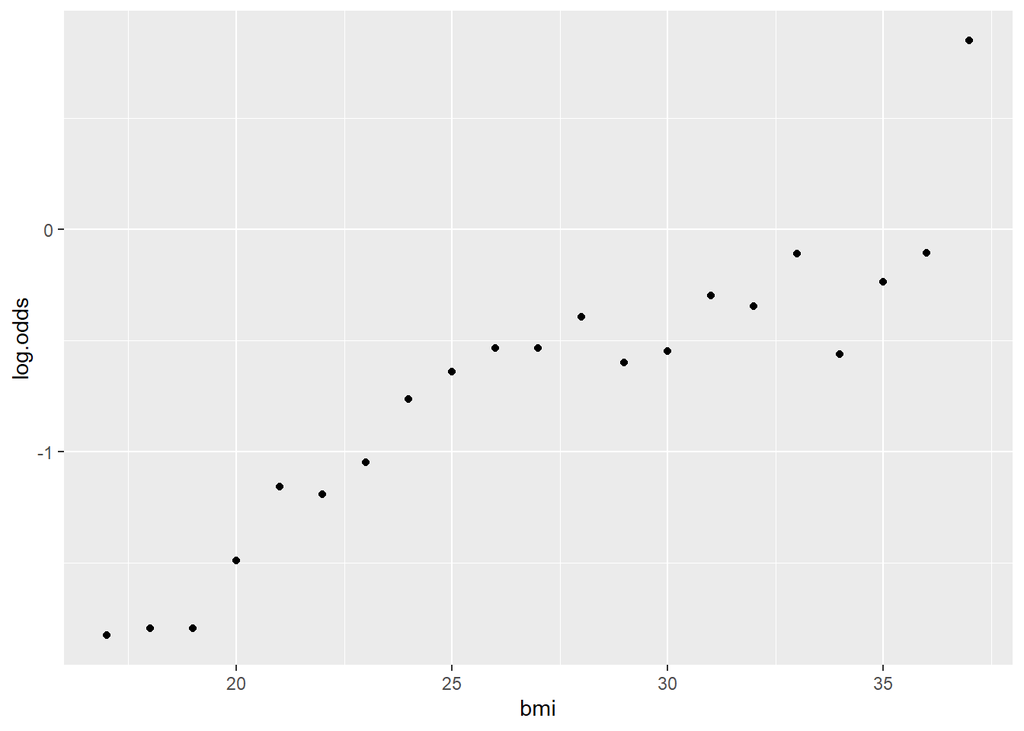

```r
heart.agg <- heart.agg %>%
  mutate(log.odds = log(odds))

ggplot(data=heart.agg, aes(x = bmi, y = log.odds)) + geom_point()
```